# red_wine_quality_prediction

## Red Wine Quality Prediction with Regression Algorithms

[figure not shown]

Alex Zhukov

10-2022

- Task Formulation - Goal, target, problem
- Data Overview - data loading, desciption, features, predictor
- Data Preprocessing - handling missing values, outliers, data wrangling
- Exploratory Data Analysis - correlations, pair plots, feature engineering, KDE, bar plots, regression plots, violin and box plots
- Machine Learning & Predictive Analysis - preparing data for modeling, modeling/training, metrics, cross-validation
- Conclusion - summary, bonus model, confusion matrix

## Task Formulation

Wine is an alcoholic beverage that has been popular for thousands of years. There are 3 main types of wine - red, white, and rose. These types of wine differ in their base and production processes. Red wine is made by fermenting the juice of dark grapes. During red wine production, the winemaker allows pressed grape juice, called must, to macerate and ferment with the dark grape skins, which adds color, flavor, and tannin to the wine. Alcohol occurs when yeast converts grape sugar into Ethanol and Carbon Dioxide.

Red wine is one of the popular alcoholic drinks nowadays and there is a variety of wine brands out there. So, often people get curious about the quality of red wine. But it becomes a quite complicated task as people don't know how to analyze wine without special knowledge. This special knowledge includes the ability to understand what kind of specific conditions affect the wine quality. Therefore, wine consumers usually rely on ratings and reviews made by a specialist. And sometimes these feedbacks are mutually exclusive and don't help to make the right decision in front of the wine shelves.

To solve this problem, we can use Python to analyze available data. This data can be used to predict the quality of the red wine given certain variables or factors.

Regression Analysis is a set of statistical methods used for the estimation of relationships between a Dependent Variable and one or more Independent Variables. In regression analysis, we used the Independent Variable (x) to estimate the Dependent Variable (y). Both of the variables that will be used must follow these requirements:

- The relationship between the variables is linear
- Both variables must be at least interval scale
- The least-squares criterion is used to determine the equation

*There are two types of Regression Analysis: Simple Linear Regression, and Multiple Linear Regression.*

**Linear Regression Model** is a way to model the relationship between two variables $$ \hat{Y} = a + bX $$ where:

- $\hat{Y}$ is the dependent variable (plotted in Y-axis)
- $X$ is the independent variable (plotted in X-axis)
- $b$ is the slope of the line
- $a$ is the y-intercept (constant)

  **Multiple Regression** a model with multiple (*k*) variables that affect the dependent variable $$ \hat{Y} = a + b_1X_1 + b_2X_2 + ... + b_kX_k$$ where:
- $X_1 ... X_k$ are the independent variables
- $a$ is the y-intercept (constant)
- $b_1$ - regression coefficient

To define the quality of red wine, there are a lot of factors. It could be the Alcohol (ABV), Sulphates, pH (a measure of how acidic/basic liquid is), etc. That’s why we need Multiple Linear Regression here.

#### So, our Goal:

- **Predict** the perfect ratio of ingredients for red wine. This is a **numerical continuous** outcome.
- **Explore** with various **Regression Models** & see which yields the **greatest accuracy**.
- Examine **trends & correlations** within our data
- Determine which **features** are important in **high quality** Red Wine

**Note:** Due to the fact that we are predicting a numerical continuous value, we will be training various Regression Models. Regression analysis is a sub field of Supervised Learning.

## Data Overview

```python
import pandas as pd
import numpy as np
from scipy import stats
import matplotlib.pyplot as plt
import seaborn as sns
sns.set()
```

Let's load data. It can be found on Kaggle.

```python
df = pd.read_csv('data/winequality-red.csv')
df.head()
```

|  | fixed acidity | volatile acidity | citric acid | residual sugar | chlorides | free sulfur dioxide | total sulfur dioxide | density | pH | sulphates | alcohol | quality |
| --- | --- | --- | --- | --- | --- | --- | --- | --- | --- | --- | --- | --- |
| 0 | 7.4 | 0.70 | 0.00 | 1.9 | 0.076 | 11.0 | 34.0 | 0.9978 | 3.51 | 0.56 | 9.4 | 5 |
| 1 | 7.8 | 0.88 | 0.00 | 2.6 | 0.098 | 25.0 | 67.0 | 0.9968 | 3.20 | 0.68 | 9.8 | 5 |
| 2 | 7.8 | 0.76 | 0.04 | 2.3 | 0.092 | 15.0 | 54.0 | 0.9970 | 3.26 | 0.65 | 9.8 | 5 |
| 3 | 11.2 | 0.28 | 0.56 | 1.9 | 0.075 | 17.0 | 60.0 | 0.9980 | 3.16 | 0.58 | 9.8 | 6 |
| 4 | 7.4 | 0.70 | 0.00 | 1.9 | 0.076 | 11.0 | 34.0 | 0.9978 | 3.51 | 0.56 | 9.4 | 5 |

**Our Predictor (Y, Wine Quality) is determined by 11 features (X):**

1. *Fixed acidity (g/L)* — most acids involved with wine or fixed or nonvolatile (do not evaporate readily)
2. *Volatile acidity (g/L)* — amount of acetic acid ( which at too high of levels can lead to an unpleasant, vinegar taste)
3. *Citric acid (mol/L)* — found in small quantities, citric acid can add ‘freshness’ and flavor to wines
4. *Residual sugar (g/L)* — amount of sugar remaining after fermentation stops
5. *Chlorides (g)* — amount of salt
6. *Free sulfur dioxide (mg/L)* — free form SO² exists equilibrium between molecular SO² (dissolved gas) and bisulfite ion
7. *Total sulfur dioxide (mg/L)* — amount of free and bound forms of SO²
8. *Density (g/cm³)* — density of water is close to that of water depending on the percent alcohol and sugar content
9. *pH* — describes how acidic or basic a wine is on a scale from 0(very acidic) to 14(very basic); most wines are between 3–4
10. *Sulfates (g)* — additive which can contribute to sulfur dioxide gas (SO²) levels, which acts as an antimicrobial
11. *Alcohol* — percent alcohol content

We have 1599 observations and 12 variables. One of those is **Quality** which is our target.

```python
df.shape
```

```
(1599, 12)
```

The number of unique values for each variable:

```python
df.nunique()
```

```
fixed acidity            96
volatile acidity        143
citric acid              80
residual sugar           91
chlorides               153
free sulfur dioxide      60
total sulfur dioxide    144
density                 436
pH                       89
sulphates                96
alcohol                  65
quality                   6
dtype: int64
```

Our data has only 1 type of data - **Continuous** - which is **quantitative data** that can be measured

```python
df.dtypes
```

```
fixed acidity           float64
volatile acidity        float64
citric acid             float64
residual sugar          float64
chlorides               float64
free sulfur dioxide     float64
total sulfur dioxide    float64
density                 float64
pH                      float64
sulphates               float64
alcohol                 float64
quality                   int64
dtype: object
```

Summarizing the main statistics - the count, mean, standard deviation, min, and max - for our numeric variables.

```python
df.describe()
```

|  | fixed acidity | volatile acidity | citric acid | residual sugar | chlorides | free sulfur dioxide | total sulfur dioxide | density | pH | sulphates | alcohol | quality |
| --- | --- | --- | --- | --- | --- | --- | --- | --- | --- | --- | --- | --- |
| count | 1599.000000 | 1599.000000 | 1599.000000 | 1599.000000 | 1599.000000 | 1599.000000 | 1599.000000 | 1599.000000 | 1599.000000 | 1599.000000 | 1599.000000 | 1599.000000 |
| mean | 8.319637 | 0.527821 | 0.270976 | 2.538806 | 0.087467 | 15.874922 | 46.467792 | 0.996747 | 3.311113 | 0.658149 | 10.422983 | 5.636023 |
| std | 1.741096 | 0.179060 | 0.194801 | 1.409928 | 0.047065 | 10.460157 | 32.895324 | 0.001887 | 0.154386 | 0.169507 | 1.065668 | 0.807569 |
| min | 4.600000 | 0.120000 | 0.000000 | 0.900000 | 0.012000 | 1.000000 | 6.000000 | 0.990070 | 2.740000 | 0.330000 | 8.400000 | 3.000000 |
| 25% | 7.100000 | 0.390000 | 0.090000 | 1.900000 | 0.070000 | 7.000000 | 22.000000 | 0.995600 | 3.210000 | 0.550000 | 9.500000 | 5.000000 |
| 50% | 7.900000 | 0.520000 | 0.260000 | 2.200000 | 0.079000 | 14.000000 | 38.000000 | 0.996750 | 3.310000 | 0.620000 | 10.200000 | 6.000000 |
| 75% | 9.200000 | 0.640000 | 0.420000 | 2.600000 | 0.090000 | 21.000000 | 62.000000 | 0.997835 | 3.400000 | 0.730000 | 11.100000 | 6.000000 |
| max | 15.900000 | 1.580000 | 1.000000 | 15.500000 | 0.611000 | 72.000000 | 289.000000 | 1.003690 | 4.010000 | 2.000000 | 14.900000 | 8.000000 |

The **mean quality** was 5.6, with its **Max** (best quality score) being 8.0 & its **Min** (worst quality score) being 3.0.

Let's take a look on the **quality scores distribution**.

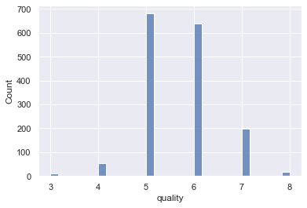

```python
sns.histplot(df.quality)
plt.show()
```

Now let's see if we have any missing values we need to take care of.

```python
df.isna().sum()
```

```
fixed acidity           0
volatile acidity        0
citric acid             0
residual sugar          0
chlorides               0
free sulfur dioxide     0
total sulfur dioxide    0
density                 0
pH                      0
sulphates               0
alcohol                 0
quality                 0
dtype: int64
```

```python
df.isna().sum().sum()
```

```
0
```

No missing values. Great!

But what about **outliers**?

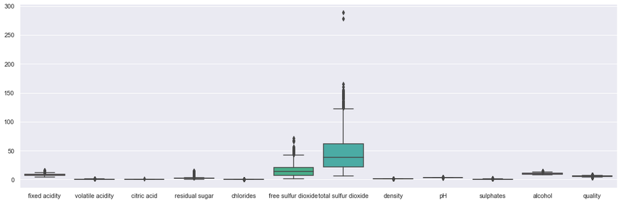

```python
plt.figure(figsize=(19,6))
sns.boxplot(data=df)
plt.show()
```

Seems that there are some harmful outliers. Let's statistically detect and remove them in the next step.

## Data Preprocessing

I will detect outliers using a **Z-score**.

**Z-score** is a measure of **position** that indicates the number of **standard deviations** a data value lies from the **mean**. Any z-score **less** thatn -3 or **greater** thah 3, is an **outlier**.

$$ Z=\frac{x-\mu}{\sigma} $$

where:

- $x$ is a score
- $\mu$ is the mean
- $\sigma$ - standard deviation

Actually **99.7%** of our data should be within **3 standard deviations** from the **mean**. All the rest to be removed.

```python
z = np.abs(stats.zscore(df)) # obtaining the z-scores of all variables
```

```python
z.head()
```

|  | fixed acidity | volatile acidity | citric acid | residual sugar | chlorides | free sulfur dioxide | total sulfur dioxide | density | pH | sulphates | alcohol | quality |
| --- | --- | --- | --- | --- | --- | --- | --- | --- | --- | --- | --- | --- |
| 0 | 0.528360 | 0.961877 | 1.391472 | 0.453218 | 0.243707 | 0.466193 | 0.379133 | 0.558274 | 1.288643 | 0.579207 | 0.960246 | 0.787823 |
| 1 | 0.298547 | 1.967442 | 1.391472 | 0.043416 | 0.223875 | 0.872638 | 0.624363 | 0.028261 | 0.719933 | 0.128950 | 0.584777 | 0.787823 |
| 2 | 0.298547 | 1.297065 | 1.186070 | 0.169427 | 0.096353 | 0.083669 | 0.229047 | 0.134264 | 0.331177 | 0.048089 | 0.584777 | 0.787823 |
| 3 | 1.654856 | 1.384443 | 1.484154 | 0.453218 | 0.264960 | 0.107592 | 0.411500 | 0.664277 | 0.979104 | 0.461180 | 0.584777 | 0.450848 |
| 4 | 0.528360 | 0.961877 | 1.391472 | 0.453218 | 0.243707 | 0.466193 | 0.379133 | 0.558274 | 1.288643 | 0.579207 | 0.960246 | 0.787823 |

Once we calculated the **z-score**, we can remove the outliers to clean our data, by performing the action below.

```python
clean_data = df[(z < 3).all(axis=1)]
```

```python
df.shape[0] - clean_data.shape[0]
```

```
148
```

We removed 148 rows which were **outliers**.

So, let's take a look at our new **cleaned up** data.

```python
clean_data.describe()
```

|  | fixed acidity | volatile acidity | citric acid | residual sugar | chlorides | free sulfur dioxide | total sulfur dioxide | density | pH | sulphates | alcohol | quality |
| --- | --- | --- | --- | --- | --- | --- | --- | --- | --- | --- | --- | --- |
| count | 1451.000000 | 1451.000000 | 1451.000000 | 1451.000000 | 1451.000000 | 1451.000000 | 1451.000000 | 1451.000000 | 1451.000000 | 1451.000000 | 1451.000000 | 1451.000000 |
| mean | 8.310062 | 0.522950 | 0.265382 | 2.387285 | 0.081425 | 15.104755 | 43.735355 | 0.996710 | 3.315934 | 0.642584 | 10.421089 | 5.659545 |
| std | 1.646458 | 0.168531 | 0.190934 | 0.862078 | 0.020966 | 9.309768 | 29.441284 | 0.001716 | 0.141096 | 0.129801 | 1.021588 | 0.781605 |
| min | 5.000000 | 0.120000 | 0.000000 | 1.200000 | 0.038000 | 1.000000 | 6.000000 | 0.991500 | 2.880000 | 0.330000 | 8.500000 | 4.000000 |
| 25% | 7.100000 | 0.390000 | 0.090000 | 1.900000 | 0.070000 | 7.000000 | 21.000000 | 0.995600 | 3.220000 | 0.550000 | 9.500000 | 5.000000 |
| 50% | 7.900000 | 0.520000 | 0.250000 | 2.200000 | 0.079000 | 13.000000 | 36.000000 | 0.996700 | 3.310000 | 0.620000 | 10.200000 | 6.000000 |
| 75% | 9.200000 | 0.630000 | 0.420000 | 2.600000 | 0.089000 | 21.000000 | 58.000000 | 0.997800 | 3.400000 | 0.720000 | 11.100000 | 6.000000 |
| max | 13.500000 | 1.040000 | 0.790000 | 6.700000 | 0.226000 | 47.000000 | 145.000000 | 1.002200 | 3.750000 | 1.160000 | 13.600000 | 8.000000 |

## EDA

#### Correlations

Let's see the **correlations** between all variables with using a **Heat Map**.

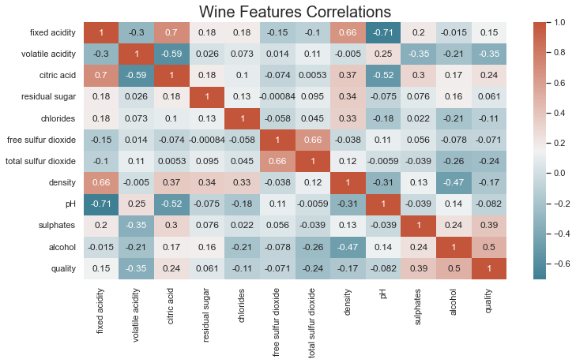

```python
corr_data = clean_data.corr()
plt.figure(figsize=(12,6))
fig = sns.heatmap(corr_data, annot=True,
            cmap=sns.diverging_palette(220, 20, as_cmap=True))
plt.title('Wine Features Correlations', fontsize = 20)
#plt.savefig('data/wine_heatmap.png')
plt.show()
```

We can see there is a **strong positive correlation** between **alcohol** and our **predictor**. In fact, this is the most correlated feature in our data set, with a value of 0.5!

**Note:** our alcohol feature was the percent alcohol content in a drink. This makes sense that a higher percent of alcohol content would yield a greater satisfaction for a customer purchasing red wine!

Next, we can see the **second strongest positive correlation**, 0.39, between **Sulphates** and our quality predictor. It seems that people rate the quality higher when an additive (SO²) is contributed to the drink. Sulphates acts as an antimicrobial.

Lastly, the **strongest negative correlation** is the **volatile acidity**, with a correlation of -0.35! This is as expected because too high acetic acid levels can lead to an unpleasant, vinegar taste!

#### Pair Plots

**Pair Plots** are also a great way to immediately see the **correlations** between all variables.

Because we have **11 Features**, lets only select **significant features** that **correlate** to our **predictor**, to further examine their **correlation** on a **Pair plot**.

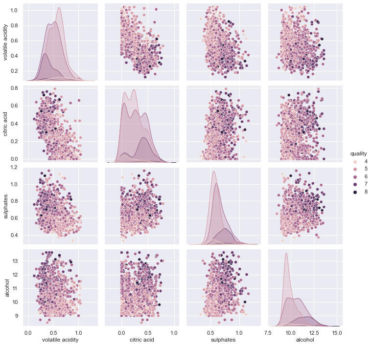

```python
significant_data = clean_data[['quality','volatile acidity', 'citric acid', 'sulphates', 'alcohol']]
sns.pairplot(significant_data, hue='quality')
plt.show()
```

#### Feature Engineering

We will now do a form of **Feature Engineering**, where we create a new column **classifying** if the wine quality is tasty or not based on its **quality score**!

This new column will be a binary Categorical Data where 0 or 1 indicates if the wine was considered “tasty”.

```python
pd.options.mode.chained_assignment = None

tasty = np.where(clean_data['quality'] < 6, 0, 1)
clean_data['tasty'] = tasty
```

```python
clean_data.head()
```

|  | fixed acidity | volatile acidity | citric acid | residual sugar | chlorides | free sulfur dioxide | total sulfur dioxide | density | pH | sulphates | alcohol | quality | tasty |
| --- | --- | --- | --- | --- | --- | --- | --- | --- | --- | --- | --- | --- | --- |
| 0 | 7.4 | 0.70 | 0.00 | 1.9 | 0.076 | 11.0 | 34.0 | 0.9978 | 3.51 | 0.56 | 9.4 | 5 | 0 |
| 1 | 7.8 | 0.88 | 0.00 | 2.6 | 0.098 | 25.0 | 67.0 | 0.9968 | 3.20 | 0.68 | 9.8 | 5 | 0 |
| 2 | 7.8 | 0.76 | 0.04 | 2.3 | 0.092 | 15.0 | 54.0 | 0.9970 | 3.26 | 0.65 | 9.8 | 5 | 0 |
| 3 | 11.2 | 0.28 | 0.56 | 1.9 | 0.075 | 17.0 | 60.0 | 0.9980 | 3.16 | 0.58 | 9.8 | 6 | 1 |
| 4 | 7.4 | 0.70 | 0.00 | 1.9 | 0.076 | 11.0 | 34.0 | 0.9978 | 3.51 | 0.56 | 9.4 | 5 | 0 |

#### Kernel Density Estimation (KDE)

A Kernel Density Estimation (KDE) estimate the probability density function (PDF) of a continuous random variable.

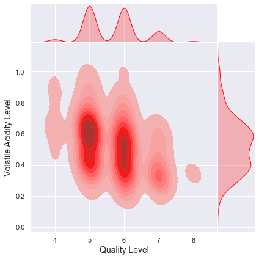

```python
g = sns.jointplot(x='quality', y='volatile acidity', data=clean_data, kind='kde', space=0, color='red', fill=True)
g.set_axis_labels('Quality Level', 'Volatile Acidity Level', fontsize=14)
plt.show()
```

Here we see that **lower quality** red wine is heavily inclined to higher levels of **volatile acidity**. This is because large quantities of acetic acid yield an unpleasant vinegar taste.

#### Regression Joint Plot

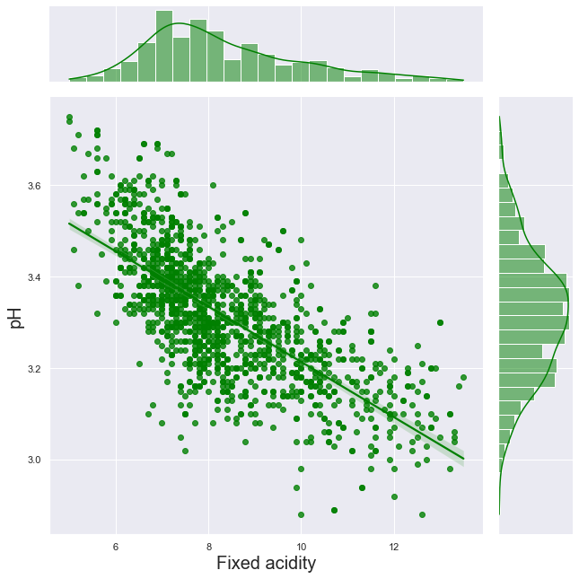

```python
g = sns.jointplot(x='fixed acidity',
                    y='pH',
                    data=clean_data,
                    kind='reg',
                    color='green',
                    height=9)

g.set_axis_labels('Fixed acidity', 'pH', fontsize=20)

plt.show()
```

From interpreting the Regression Joint plot above, we can see a **Strong Negative correlation** between **pH** level and **fixed acidity**. In other words, as one of these increases, the other decreases. According to the **HeatMap**, these two features have a **correlation** coefficent of **-0.71**

#### Bar Plots

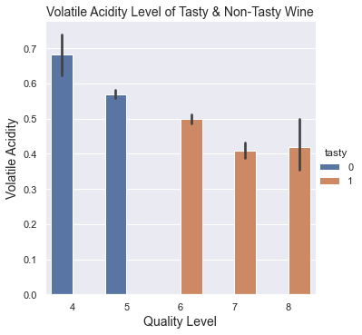

```python
sns.catplot(x='quality', y='volatile acidity', hue='tasty',
            data=clean_data, kind='bar')
plt.title('Volatile Acidity Level of Tasty & Non-Tasty Wine', fontsize=14)
plt.xlabel('Quality Level', fontsize=14)
plt.ylabel('Volatile Acidity', fontsize=14)

plt.show()
```

This plot again illustrates that high volatile acidity levels yield a terrible tasting wine.

#### Violin & Box Plots

The advantages of the **Box & Violin** plot is that it shows the **basic statistics** of the data, as well as its **distribution**.

So, let's see the **median**, **IQR**, & **Tukey’s fence**. (minimum, first quartile (Q1), median, third quartile (Q3), and maximum).

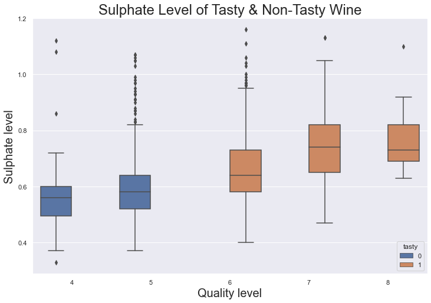

```python
plt.figure(figsize=(12, 8))
sns.boxplot(x='quality', y='sulphates', hue='tasty', data=clean_data)
plt.title('Sulphate Level of Tasty & Non-Tasty Wine', fontsize=24)
plt.xlabel('Quality level', fontsize=20)
plt.ylabel('Sulphate level', fontsize=20)

plt.show()
```

Next, we examine this **box plot** that helps to conclude that a tasty red wine exhibits **heightened median** for **Sulfate** levels.

We can see now that these high sulfate levels would enhance a customers preference.

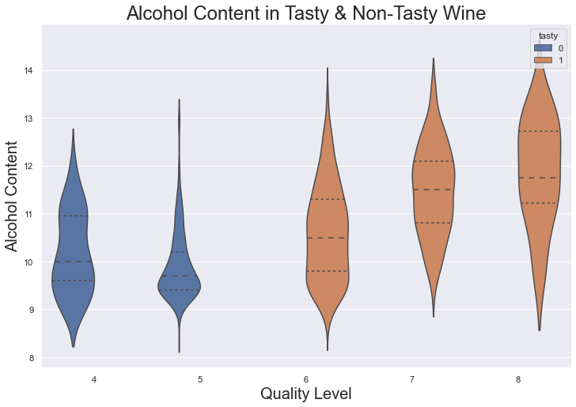

```python
plt.figure(figsize=(12, 8))
sns.violinplot(x='quality', y='alcohol', hue='tasty',
               inner='quartile',
               data=clean_data)
plt.title('Alcohol Content in Tasty & Non-Tasty Wine',fontsize=24)
plt.xlabel('Quality Level', fontsize=20)
plt.ylabel('Alcohol Content', fontsize=20)

plt.show()
```

After analyzing this **violin plot** we can conclude that the overall shape & distribution for tasty & non-tasty wine **differ vastly**. **Tasty** red wine exhibits a **higher median** for percent **alcohol** content & thus a great distribution of it is between 10 and 13, while **non-tasty** red wine consists of a **lower median alcohol** level content between 9.5 and 11.

Let's now compare the **averages** between **tasty** and **non-tasty** red wine.

```python
tasty = clean_data[clean_data['tasty'] == 1]
tasty.describe()
```

|  | fixed acidity | volatile acidity | citric acid | residual sugar | chlorides | free sulfur dioxide | total sulfur dioxide | density | pH | sulphates | alcohol | quality | tasty |
| --- | --- | --- | --- | --- | --- | --- | --- | --- | --- | --- | --- | --- | --- |
| count | 787.000000 | 787.000000 | 787.000000 | 787.000000 | 787.000000 | 787.000000 | 787.000000 | 787.000000 | 787.000000 | 787.000000 | 787.000000 | 787.000000 | 787.0 |
| mean | 8.485642 | 0.477541 | 0.295286 | 2.400762 | 0.079785 | 14.560356 | 36.626429 | 0.996481 | 3.311868 | 0.682579 | 10.833990 | 6.275731 | 1.0 |
| std | 1.748845 | 0.162388 | 0.197117 | 0.871710 | 0.022654 | 9.061416 | 21.715608 | 0.001856 | 0.137032 | 0.127242 | 1.054157 | 0.490581 | 0.0 |
| min | 5.100000 | 0.120000 | 0.000000 | 1.200000 | 0.038000 | 1.000000 | 6.000000 | 0.991500 | 2.880000 | 0.400000 | 8.700000 | 6.000000 | 1.0 |
| 25% | 7.200000 | 0.360000 | 0.105000 | 1.900000 | 0.067000 | 7.000000 | 20.000000 | 0.995220 | 3.220000 | 0.590000 | 10.000000 | 6.000000 | 1.0 |
| 50% | 8.100000 | 0.460000 | 0.310000 | 2.200000 | 0.077000 | 13.000000 | 31.000000 | 0.996400 | 3.310000 | 0.660000 | 10.800000 | 6.000000 | 1.0 |
| 75% | 9.650000 | 0.582500 | 0.450000 | 2.550000 | 0.087000 | 19.000000 | 48.000000 | 0.997600 | 3.400000 | 0.760000 | 11.600000 | 7.000000 | 1.0 |
| max | 13.400000 | 1.040000 | 0.760000 | 6.700000 | 0.226000 | 45.000000 | 114.000000 | 1.002200 | 3.710000 | 1.160000 | 13.600000 | 8.000000 | 1.0 |

```python
nontasty = clean_data[clean_data['tasty'] == 0]
nontasty.describe()
```

|  | fixed acidity | volatile acidity | citric acid | residual sugar | chlorides | free sulfur dioxide | total sulfur dioxide | density | pH | sulphates | alcohol | quality | tasty |
| --- | --- | --- | --- | --- | --- | --- | --- | --- | --- | --- | --- | --- | --- |
| count | 664.000000 | 664.000000 | 664.000000 | 664.000000 | 664.000000 | 664.000000 | 664.000000 | 664.000000 | 664.000000 | 664.000000 | 664.000000 | 664.000000 | 664.0 |
| mean | 8.101958 | 0.576770 | 0.229940 | 2.371310 | 0.083369 | 15.750000 | 52.161145 | 0.996981 | 3.320753 | 0.595181 | 9.931702 | 4.929217 | 0.0 |
| std | 1.490911 | 0.159709 | 0.177049 | 0.850899 | 0.018601 | 9.562567 | 34.721033 | 0.001489 | 0.145722 | 0.116208 | 0.723074 | 0.256656 | 0.0 |
| min | 5.000000 | 0.180000 | 0.000000 | 1.200000 | 0.039000 | 3.000000 | 6.000000 | 0.992560 | 2.880000 | 0.330000 | 8.500000 | 4.000000 | 0.0 |
| 25% | 7.100000 | 0.460000 | 0.080000 | 1.900000 | 0.074000 | 8.000000 | 23.000000 | 0.996100 | 3.220000 | 0.520000 | 9.400000 | 5.000000 | 0.0 |
| 50% | 7.800000 | 0.580000 | 0.220000 | 2.200000 | 0.080000 | 14.000000 | 43.000000 | 0.996900 | 3.320000 | 0.570000 | 9.700000 | 5.000000 | 0.0 |
| 75% | 8.825000 | 0.670000 | 0.350000 | 2.600000 | 0.090000 | 21.250000 | 72.000000 | 0.997823 | 3.410000 | 0.640000 | 10.300000 | 5.000000 | 0.0 |
| max | 13.500000 | 1.040000 | 0.790000 | 6.600000 | 0.186000 | 47.000000 | 145.000000 | 1.001800 | 3.750000 | 1.120000 | 13.000000 | 5.000000 | 0.0 |

```python
print(f'Tasty Wine Sulphates Level: {tasty["sulphates"].mean()}')
print(f'Non-Tasty Wine Sulphates Level: {nontasty["sulphates"].mean()}')
print()
print(f'Tasty Wine Alcohol Content Level: {tasty["alcohol"].mean()}')
print(f'Non-Tasty Wine Alcohol Content Level: {nontasty["alcohol"].mean()}')
print()
print(f'Tasty Wine Total Sulfur Dioxide level: {tasty["total sulfur dioxide"].mean()}')
print(f'Non-Tasty Wine Total Sulfur Dioxide level: {nontasty["total sulfur dioxide"].mean()}')
```

```
Tasty Wine Sulphates Level: 0.6825794155019054
Non-Tasty Wine Sulphates Level: 0.5951807228915662

Tasty Wine Alcohol Content Level: 10.833989834815748
Non-Tasty Wine Alcohol Content Level: 9.931701807228912

Tasty Wine Total Sulfur Dioxide level: 36.62642947903431
Non-Tasty Wine Total Sulfur Dioxide level: 52.161144578313255
```

**Tastier** Wine exhibits **higher** levels of **Sulphates** and **Alcohol** and **lower** level of Total Sulfur Dioxid.

Therefore, to maximize the sales of red wine, wine producer need to include low levels of **sulfur dioxide** and **high** levels of **sulphates** and **alcohol**.

## Predictive Analysis

### Prepare Data for Modeling

**Assign** the 11 features to X, and the `quality` column to our predictor - y

```python
X = clean_data.drop(['quality', 'tasty'], axis=1)
y = clean_data.quality
```

**Split** the dataset into the Training set and Test set

```python
from sklearn.model_selection import train_test_split
x_train, x_test, y_train, y_test = train_test_split(X, y, test_size=.2, random_state=1)
```

**Normalizing** the data - transforming it so that its distribution will have a mean of 0 and a standard deviation of 1.

```python
from sklearn.preprocessing import StandardScaler
sc = StandardScaler()
x_train = sc.fit_transform(x_train)
x_test = sc.transform(x_test)
```

### Modeling/Training

Now I'm going to train various **Regression Models** on the **Training set** and see which yields the **highest accuracy**. I will compare the accuracy of **Multiple Linear Regression, Ridge Regression, SVR (Support Vector Regression), Decision Tree Regression, Random Forest Regression, and XGBoost.** These are **supervised learning** models, for predicting continuous values.

**Note:** There are a few metrics for measuring accuracy for a regression model like **Root Mean Squared Error (RMSE), Residual Standard Error (RSE),** R²**, and** Mean Squared Error (MSE)**. But I will be measuring our models with** Mean Absolute Error (MAE)__

```python
from sklearn.metrics import mean_absolute_error, r2_score, accuracy_score
```

#### Model 1: Multiple Linear Regression

```python
from sklearn.linear_model import LinearRegression

# Train model on the train dataset
reg1 = LinearRegression()
reg1.fit(x_train, y_train)

# predicting the test dataset
y_pred1 = reg1.predict(x_test)

# Evaluating model performance
print(f'MAE: {mean_absolute_error(y_test, y_pred1)}\n \
      Train data r2 score: {reg1.score(x_train, y_train)}\n \
      Test data r2 score: {r2_score(y_test, y_pred1)}')
```

```
MAE: 0.4939537644033682
       Train data r2 score: 0.40505473059191754
       Test data r2 score: 0.25451438574191876
```

#### Model 2: Ridge Regression

```python
from sklearn.linear_model import Ridge
reg2 = Ridge()
reg2.fit(x_train, y_train)
y_pred2 = reg2.predict(x_test)

print(f'MAE: {mean_absolute_error(y_test, y_pred2)}\n \
      Train data r2 score: {reg2.score(x_train, y_train)}\n \
      Test data r2 score: {r2_score(y_test, y_pred2)}')
```

```
MAE: 0.4939240146691417
       Train data r2 score: 0.40505434091133596
       Test data r2 score: 0.2546478172026633
```

#### Model 3: Support Vector Regression

```python
from sklearn.svm import SVR
reg3 = SVR()
reg3.fit(x_train, y_train)
y_pred3 = reg3.predict(x_test)

print(f'MAE: {mean_absolute_error(y_test, y_pred3)}\n \
      Train data r2 score: {reg3.score(x_train, y_train)}\n \
      Test data r2 score: {r2_score(y_test, y_pred3)}')
```

```
MAE: 0.45410837591861164
       Train data r2 score: 0.6070471406274619
       Test data r2 score: 0.2904305638776502
```

#### Model 4: Decision Tree Regression

```python
from sklearn.tree import DecisionTreeRegressor
reg4 = DecisionTreeRegressor(criterion='poisson', max_depth=3, max_leaf_nodes=4)
reg4.fit(x_train, y_train)
y_pred4 = reg4.predict(x_test)

print(f'MAE: {mean_absolute_error(y_test, y_pred4)}\n \
      Train data r2 score: {reg4.score(x_train, y_train)}\n \
      Test data r2 score: {r2_score(y_test, y_pred4)}')
```

```
MAE: 0.5433287304626896
       Train data r2 score: 0.2969643822023026
       Test data r2 score: 0.18116070615480218
```

#### Model 5: Random Forest Regression

```python
from sklearn.ensemble import RandomForestRegressor
reg5 = RandomForestRegressor(n_estimators = 200, max_depth=13 , random_state=0)
reg5.fit(x_train, y_train)
y_pred5= reg5.predict(x_test)

print(f'MAE: {mean_absolute_error(y_test, y_pred5)}\n \
      Train data r2 score: {reg5.score(x_train, y_train)}\n \
      Test data r2 score: {r2_score(y_test, y_pred5)}')
```

```
MAE: 0.4226459192249129
       Train data r2 score: 0.916430096255789
       Test data r2 score: 0.3687445367908615
```

#### Model 6: Gradient Boost Regression

```python
from xgboost import XGBRegressor
reg6 = XGBRegressor()
reg6.fit(x_train, y_train)
y_pred6 = reg6.predict(x_test)

print(f'MAE: {mean_absolute_error(y_test, y_pred6)}\n \
      Train data r2 score: {reg6.score(x_train, y_train)}\n \
      Test data r2 score: {r2_score(y_test, y_pred6)}')
```

```
MAE: 0.4055099143195398
       Train data r2 score: 0.9970469089757216
       Test data r2 score: 0.3386095956511733
```

#### Model 7: K-Neighbors Regression

```python
from sklearn.neighbors import KNeighborsRegressor
reg7 = KNeighborsRegressor()
reg7.fit(x_train, y_train)
y_pred7 = reg7.predict(x_test)

print(f'MAE: {mean_absolute_error(y_test, y_pred7)}\n \
      Train data r2 score: {reg7.score(x_train, y_train)}\n \
      Test data r2 score: {r2_score(y_test, y_pred7)}')
```

```
MAE: 0.5429553264604811
       Train data r2 score: 0.563044328015119
       Test data r2 score: 0.08433500021011031
```

#### Among all these models, XGboost shows the most accurate result.

Therefore I will try to tune this model to improve its accuracy. Best parameters for the model can be made found using **GridSearchCV**.

```python
from sklearn.model_selection import GridSearchCV

xgb_reg = XGBRegressor()

params = {    'learning_rate': [.03, 0.05, .07],
              'max_depth': [12, 14, 16],
              'min_child_weight': [4],
              'subsample': [0.7],
              'colsample_bytree': [0.7],
              'n_estimators': [500]
         }
grid_xgb_reg=GridSearchCV(xgb_reg,
                          param_grid=params,
                          cv=3,
                          n_jobs=-1)

grid_xgb_reg.fit(x_train, y_train)
best_model = grid_xgb_reg.best_estimator_
y_pred11 = best_model.predict(x_test)
```

```python
print(f'MAE: {mean_absolute_error(y_test, y_pred11)}\n \
      Train data r2 score: {grid_xgb_reg.score(x_train, y_train)}\n \
      Test data r2 score: {r2_score(y_test, y_pred11)}')
```

```
MAE: 0.3801590486900094
       Train data r2 score: 0.999922648571115
       Test data r2 score: 0.3803333214790495
```

## Conclusion

We found that XGBoost Regression is the best model for our task that provides 0.38 MAE which is relatively good result. Having our target variable range from 4 to 8 we have an average error of 0.38.

However, there's one **important point** that we have to keep in mind.

In this project we considered our predictor as a **continuous numerical target**. And that is not 100% correct. The score of the red wine can be either 4, 5, 6, 7 or 8. And this is more likely a **nominal** variable with **5 categories** (or even **ordinal**) but not **continuous** as we assumed earlier in this project. Therefore, when we apply **linear regression** models we got continuous results in the range between 4 and 8. Of course we still can evaluate the red wine quality based on the floating number score we got, but the correct way would be to perform **multinominal logistic regression** or **classification** techniques in this task. And these models will work with even better result.

Let's see just one example below.

```python
# convert our target into categories from 0 to 4
y_train_log = y_train-4
y_test_log = y_test-4
```

```python
# apply gradient boost classifier
from xgboost import XGBClassifier

clf = XGBClassifier()
clf.fit(x_train, y_train_log)

y_pred_log = clf.predict(x_test)
```

```python
print(f'MAE: {mean_absolute_error(y_test_log, y_pred_log)}\nAccuracy score: {accuracy_score(y_test_log, y_pred_log)}')
```

```
MAE: 0.28865979381443296
Accuracy score: 0.7491408934707904
```

#### And finally let's look at confusion matrix

```python
from sklearn.metrics import confusion_matrix, plot_confusion_matrix
cf = confusion_matrix(y_test_log, y_pred_log)

cf
```

```
array([[  1,   5,   3,   0,   0],
       [  0, 108,  22,   2,   0],
       [  1,  14,  95,   8,   0],
       [  0,   3,  11,  14,   1],
       [  0,   0,   2,   1,   0]], dtype=int64)
```

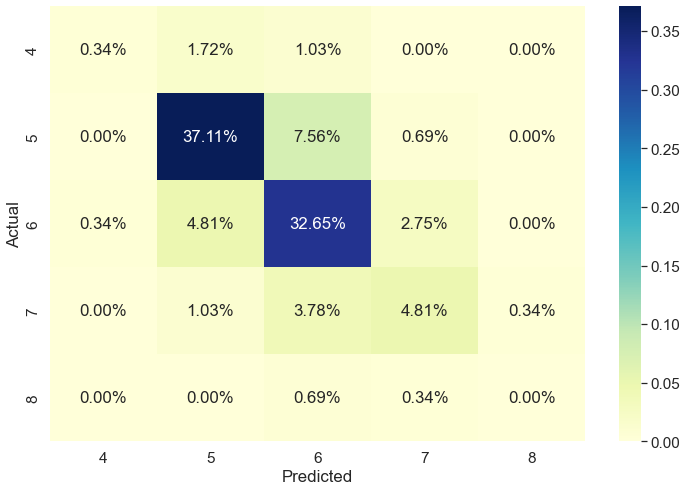

```python
df_cm = pd.DataFrame(cf, columns=np.unique(y_test), index = np.unique(y_test))
df_cm.index.name = 'Actual'
df_cm.columns.name = 'Predicted'

plt.figure(figsize = (12,8))
sns.set(font_scale=1.4)
sns.heatmap(df_cm/np.sum(cf), cmap="YlGnBu",  fmt='.2%', annot=True)
plt.show()
```